# cancer cancer survival analysis (female vs male)

## Format

inst: Institution code time: Survival time in days

status: censoring status 1=censored, 2=dead

age: Age in years

sex: Male=1 Female=2

ph.ecog: ECOG performance score as rated by the physician. 0=asymptomatic, 1= symptomatic but completely ambulatory, 2= in bed <50% of the day, 3= in bed > 50% of the day but not bedbound, 4 = bedbound

ph.karno: Karnofsky performance score (bad=0-good=100) rated by physician

pat.karno: Karnofsky performance score as rated by patient

meal.cal: Calories consumed at meals

wt.loss: Weight loss in last six months (pounds)

## Note

The use of 1/2 for alive/dead instead of the usual 0/1 is a historical footnote. For data contained on punch cards, IBM 360 Fortran treated blank as a zero, which led to a policy within the section of Biostatistics to never use “0” as a data value since one could not distinguish it from a missing value. The policy became a habit, as is often the case; and the 1/2 coding endured long beyond the demise of punch cards and Fortran.

## Source

Terry Therneau

## References

Loprinzi CL. Laurie JA. Wieand HS. Krook JE. Novotny PJ. Kugler JW. Bartel J. Law M. Bateman M. Klatt NE. et al. Prospective evaluation of prognostic variables from patient-completed questionnaires. North Central Cancer Treatment Group. Journal of Clinical Oncology. 12(3):601-7, 1994.

```r
library(dplyr)
library(DataExplorer)
library(survival)
library(survminer)
library(gmodels)
library(ggplot2)
library(tidyverse)
library(readxl)
library(epiDisplay)
library(pivottabler)
library(arsenal)
```

```r
# Load the survival package
library(survival)

# Load the cancer dataset from the survival package
data(cancer, package = "survival")
```

## Exploratory Data Analysis

```r
# Dimensions of the dataset
dim(cancer)
```

```
[1] 228  10
```

```r
# Structure of the dataset
str(cancer)
```

```
'data.frame':   228 obs. of  10 variables:
 $ inst     : num  3 3 3 5 1 12 7 11 1 7 ...
 $ time     : num  306 455 1010 210 883 ...
 $ status   : num  2 2 1 2 2 1 2 2 2 2 ...
 $ age      : num  74 68 56 57 60 74 68 71 53 61 ...
 $ sex      : num  1 1 1 1 1 1 2 2 1 1 ...
 $ ph.ecog  : num  1 0 0 1 0 1 2 2 1 2 ...
 $ ph.karno : num  90 90 90 90 100 50 70 60 70 70 ...
 $ pat.karno: num  100 90 90 60 90 80 60 80 80 70 ...
 $ meal.cal : num  1175 1225 NA 1150 NA ...
 $ wt.loss  : num  NA 15 15 11 0 0 10 1 16 34 ...
```

```r
# First few rows of the dataset
head(cancer)
```

|  | inst | time | status | age | sex | ph.ecog | ph.karno | pat.karno | meal.cal | wt.loss |
| --- | --- | --- | --- | --- | --- | --- | --- | --- | --- | --- |
| 1 | 3 | 306 | 2 | 74 | 1 | 1 | 90 | 100 | 1175 | NA |
| 2 | 3 | 455 | 2 | 68 | 1 | 0 | 90 | 90 | 1225 | 15 |
| 3 | 3 | 1010 | 1 | 56 | 1 | 0 | 90 | 90 | NA | 15 |
| 4 | 5 | 210 | 2 | 57 | 1 | 1 | 90 | 60 | 1150 | 11 |
| 5 | 1 | 883 | 2 | 60 | 1 | 0 | 100 | 90 | NA | 0 |
| 6 | 12 | 1022 | 1 | 74 | 1 | 1 | 50 | 80 | 513 | 0 |

```r
# Concise summary of the dataset
glimpse(cancer)
```

```
Rows: 228
Columns: 10
$ inst      <dbl> 3, 3, 3, 5, 1, 12, 7, 11, 1, 7, 6, 16, 11, 21, 12, 1, 22, 16, 1, 21, 11, 6, 11, 15, 12, 12, 4, 13, 13, 1, 12, 1, 7, 16, 12, 1, 22, 15, 1, 1, 5, 11, 10, 12, 7, 7, 1, 3…
$ time      <dbl> 306, 455, 1010, 210, 883, 1022, 310, 361, 218, 166, 170, 654, 728, 71, 567, 144, 613, 707, 61, 88, 301, 81, 624, 371, 394, 520, 574, 118, 390, 12, 473, 26, 533, 107, …
$ status    <dbl> 2, 2, 1, 2, 2, 1, 2, 2, 2, 2, 2, 2, 2, 2, 2, 2, 2, 2, 2, 2, 2, 2, 2, 2, 2, 2, 2, 2, 2, 2, 2, 2, 2, 2, 2, 2, 2, 1, 2, 2, 2, 2, 2, 2, 2, 2, 2, 2, 2, 2, 2, 2, 2, 2, 2, 2…
$ age       <dbl> 74, 68, 56, 57, 60, 74, 68, 71, 53, 61, 57, 68, 68, 60, 57, 67, 70, 63, 56, 57, 67, 49, 50, 58, 72, 70, 60, 70, 53, 74, 69, 73, 48, 60, 61, 62, 65, 66, 74, 64, 70, 73…
$ sex       <dbl> 1, 1, 1, 1, 1, 1, 2, 2, 1, 1, 1, 2, 2, 1, 1, 1, 1, 1, 2, 1, 1, 2, 1, 1, 1, 2, 1, 1, 1, 1, 2, 1, 1, 2, 1, 2, 1, 2, 1, 2, 1, 2, 2, 2, 1, 2, 1, 1, 1, 2, 2, 1, 1, 1, 1, 1…
$ ph.ecog   <dbl> 1, 0, 0, 1, 0, 1, 2, 2, 1, 2, 1, 2, 1, NA, 1, 1, 1, 2, 2, 1, 1, 0, 1, 0, 0, 1, 0, 3, 1, 2, 1, 2, 2, 2, 2, 2, 2, 1, 2, 1, 1, 2, 0, 2, 1, 2, 0, 1, 0, 1, 1, 0, 0, 0, 1, …
$ ph.karno  <dbl> 90, 90, 90, 90, 100, 50, 70, 60, 70, 70, 80, 70, 90, 60, 80, 80, 90, 50, 60, 90, 80, 100, 70, 90, 90, 90, 100, 60, 80, 70, 90, 60, 60, 50, 70, 50, 70, 70, 50, 80, 80,…
$ pat.karno <dbl> 100, 90, 90, 60, 90, 80, 60, 80, 80, 70, 80, 70, 90, 70, 70, 90, 100, 70, 60, 80, 80, 70, 80, 100, 80, 80, 100, 70, 70, 50, 90, 70, 80, 60, 100, 50, 60, 90, 40, 100, …
$ meal.cal  <dbl> 1175, 1225, NA, 1150, NA, 513, 384, 538, 825, 271, 1025, NA, NA, 1225, 2600, NA, 1150, 1025, 238, 1175, 1025, 1175, NA, 975, NA, 825, 1025, 1075, 875, 305, 1025, 388,…
$ wt.loss   <dbl> NA, 15, 15, 11, 0, 0, 10, 1, 16, 34, 27, 23, 5, 32, 60, 15, -5, 22, 10, NA, 17, -8, 16, 13, 0, 6, -13, 20, -7, 20, -1, 20, -11, -15, 10, NA, 28, 4, 24, 15, 10, 11, 27…
```

```r
# Summary statistics
summary(cancer)
```

```
      inst           time          status          age            sex          ph.ecog         ph.karno       pat.karno      meal.cal       wt.loss
 Min.   : 1.0   Min.   :   5   Min.   :1.00   Min.   :39.0   Min.   :1.00   Min.   :0.000   Min.   : 50.0   Min.   : 30   Min.   :  96   Min.   :-24.00
 1st Qu.: 3.0   1st Qu.: 167   1st Qu.:1.00   1st Qu.:56.0   1st Qu.:1.00   1st Qu.:0.000   1st Qu.: 75.0   1st Qu.: 70   1st Qu.: 635   1st Qu.:  0.00
 Median :11.0   Median : 256   Median :2.00   Median :63.0   Median :1.00   Median :1.000   Median : 80.0   Median : 80   Median : 975   Median :  7.00
 Mean   :11.1   Mean   : 305   Mean   :1.72   Mean   :62.4   Mean   :1.39   Mean   :0.952   Mean   : 81.9   Mean   : 80   Mean   : 929   Mean   :  9.83
 3rd Qu.:16.0   3rd Qu.: 396   3rd Qu.:2.00   3rd Qu.:69.0   3rd Qu.:2.00   3rd Qu.:1.000   3rd Qu.: 90.0   3rd Qu.: 90   3rd Qu.:1150   3rd Qu.: 15.75
 Max.   :33.0   Max.   :1022   Max.   :2.00   Max.   :82.0   Max.   :2.00   Max.   :3.000   Max.   :100.0   Max.   :100   Max.   :2600   Max.   : 68.00
 NA's   :1                                                                  NA's   :1       NA's   :1       NA's   :3     NA's   :47     NA's   :14
```

Inst, status, sex and ph.ecog –> factor

```r
#Change numeric variable to factor
cancer$inst <- as.factor(cancer$inst)
cancer$status <- as.factor(cancer$status)
cancer$sex <- as.factor(cancer$sex)
cancer$ph.ecog <- as.factor(cancer$ph.ecog)
summary(cancer)
```

```
      inst          time      status       age       sex     ph.ecog       ph.karno       pat.karno      meal.cal       wt.loss
 1      : 36   Min.   :   5   1: 63   Min.   :39.0   1:138   0   : 63   Min.   : 50.0   Min.   : 30   Min.   :  96   Min.   :-24.00
 12     : 23   1st Qu.: 167   2:165   1st Qu.:56.0   2: 90   1   :113   1st Qu.: 75.0   1st Qu.: 70   1st Qu.: 635   1st Qu.:  0.00
 13     : 20   Median : 256           Median :63.0           2   : 50   Median : 80.0   Median : 80   Median : 975   Median :  7.00
 3      : 19   Mean   : 305           Mean   :62.4           3   :  1   Mean   : 81.9   Mean   : 80   Mean   : 929   Mean   :  9.83
 11     : 18   3rd Qu.: 396           3rd Qu.:69.0           NA's:  1   3rd Qu.: 90.0   3rd Qu.: 90   3rd Qu.:1150   3rd Qu.: 15.75
 (Other):111   Max.   :1022           Max.   :82.0                      Max.   :100.0   Max.   :100   Max.   :2600   Max.   : 68.00
 NA's   :  1                                                            NA's   :1       NA's   :3     NA's   :47     NA's   :14
```

NA : inst, ph.karno, pat.karno, meal.cal, wt.loss

## Exploration of numeric data

```r
# Grouping the numeric variables
num <- c("time","age","ph.karno","pat.karno","meal.cal","wt.loss")
```

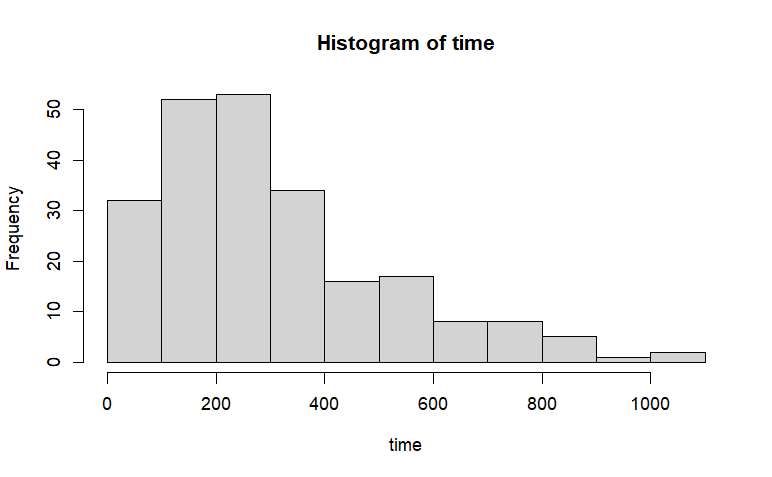

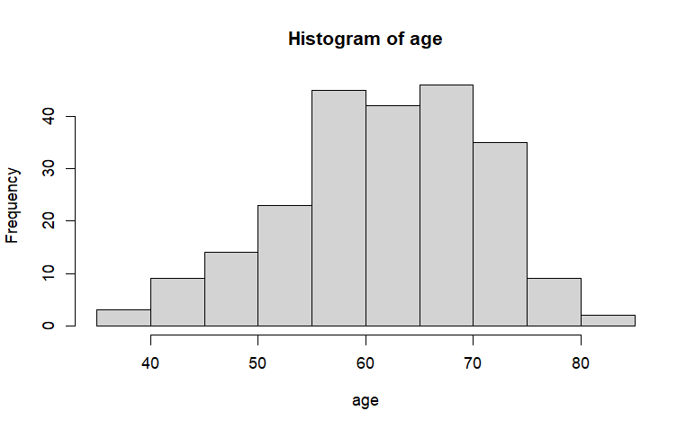

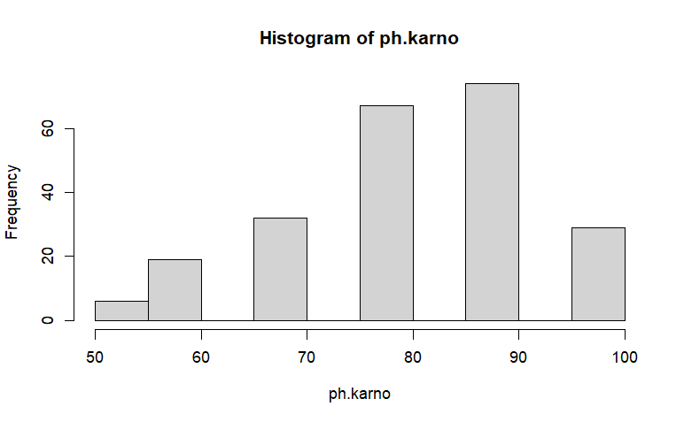

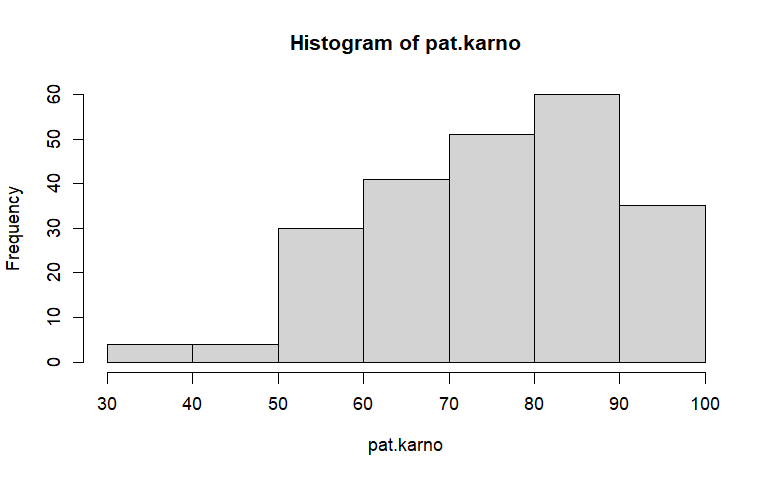

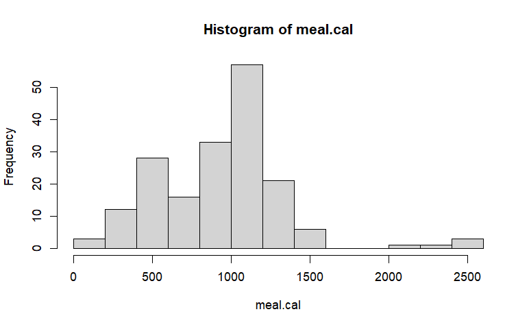

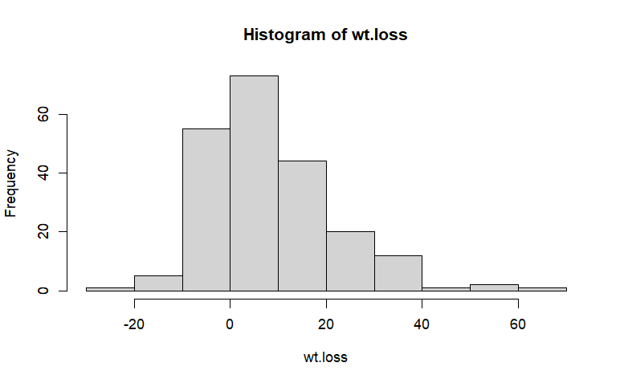

```r
# Create repeated histograms for each categorical variable
for(var in num) {
  hist(cancer[[var]], main = paste("Histogram of", var), xlab = var)
}
```

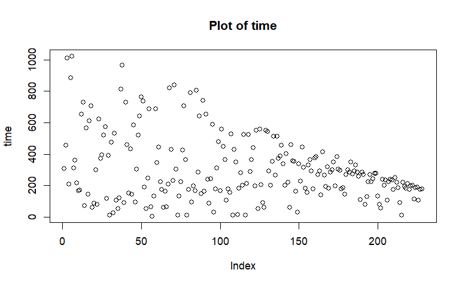

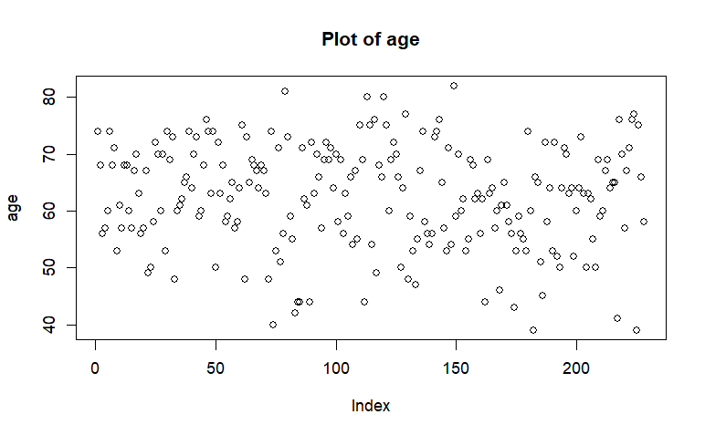

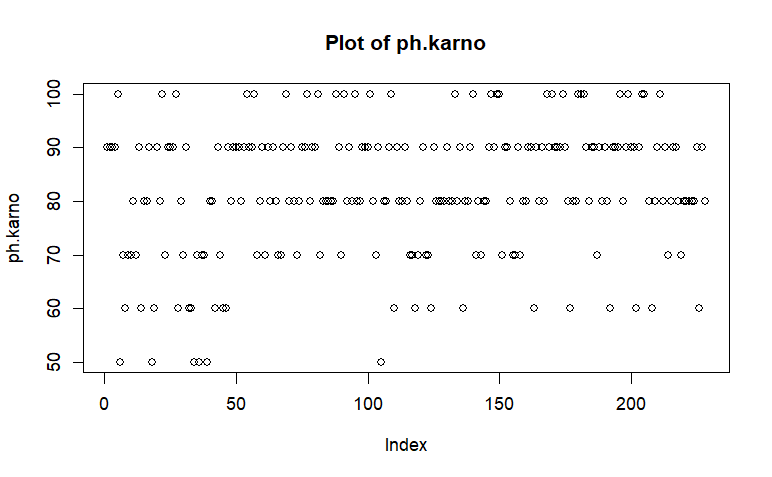

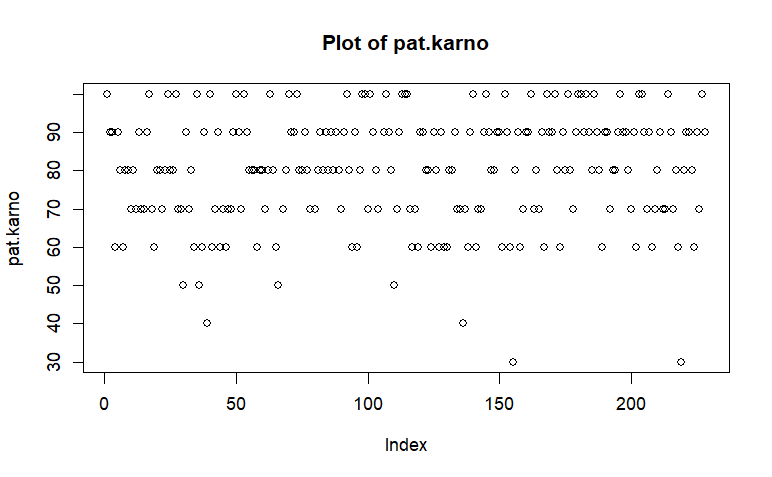

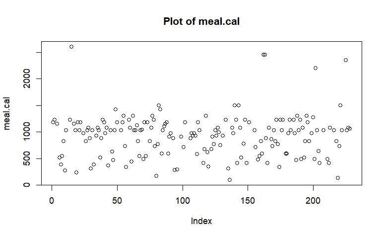

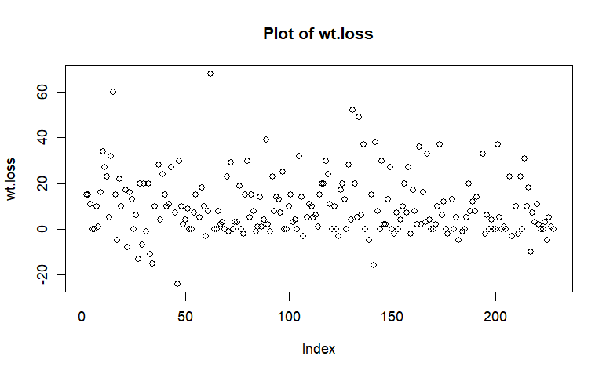

```r
# Create repeated plots for each numerical variable
for(var in num) {
  plot(cancer[[var]], main = paste("Plot of", var), xlab = "Index", ylab = var)
}
```

```
Shapiro-Wilk Test Result for time :

    Shapiro-Wilk normality test

data:  cancer[[var]]
W = 0.9165, p-value = 0.000000000511

Shapiro-Wilk Test Result for age :

    Shapiro-Wilk normality test

data:  cancer[[var]]
W = 0.9817, p-value = 0.00483
```

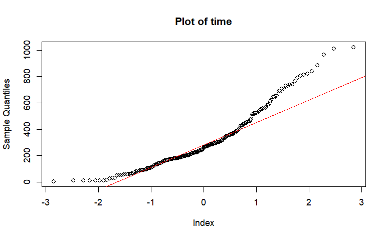

```
Shapiro-Wilk Test Result for ph.karno :

    Shapiro-Wilk normality test

data:  cancer[[var]]
W = 0.9095, p-value = 0.000000000166
```

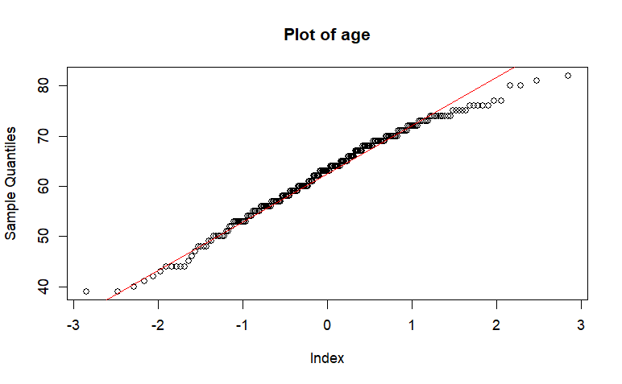

```
Shapiro-Wilk Test Result for pat.karno :

    Shapiro-Wilk normality test

data:  cancer[[var]]
W = 0.92, p-value = 0.00000000113
```

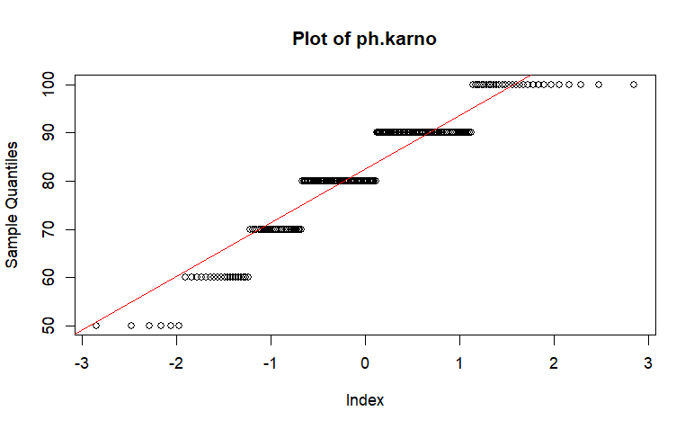

```
Shapiro-Wilk Test Result for meal.cal :

    Shapiro-Wilk normality test

data:  cancer[[var]]
W = 0.9049, p-value = 0.00000000214
```

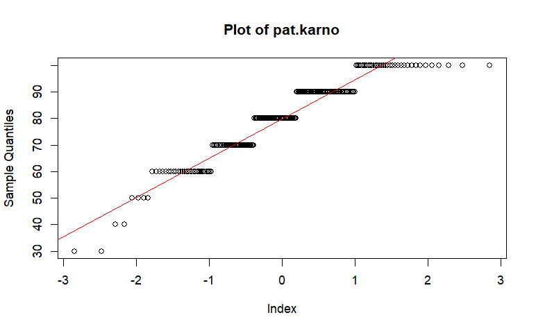

```
Shapiro-Wilk Test Result for wt.loss :

    Shapiro-Wilk normality test

data:  cancer[[var]]
W = 0.9149, p-value = 0.000000000965
```

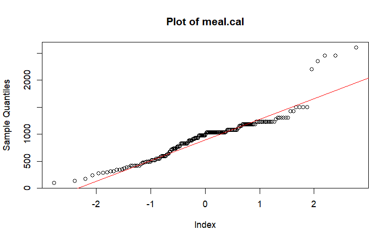

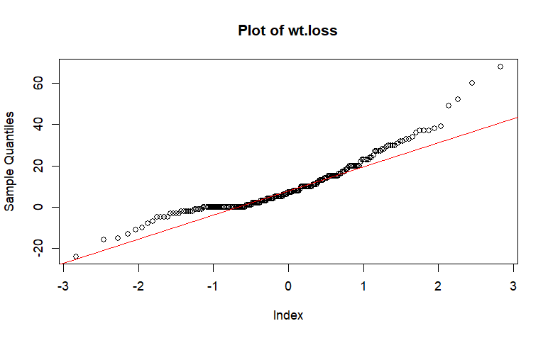

```r
# Normality test using Saphiro and QQ-plot
for(var in num) {
  # Perform the Shapiro-Wilk test
shapiro_result <- shapiro.test(cancer[[var]])

# Print the result with a title
cat("Shapiro-Wilk Test Result for", var, ":\n")
print(shapiro_result)

# Create the Q-Q plot
qqnorm(cancer[[var]], main = paste("Plot of", var), xlab = "Index")
qqline(cancer[[var]], col = "red")
}
```

note : all numeric variables are not normally distributed

```r
#Grouping the categorical variables
cat <- cancer[,c("inst", "status","sex", "ph.ecog")]
```

```r
# Describe the categorical data
describe(cat)
```

```
cat

 4  Variables      228  Observations
------------------------------------------------------------------------------------------------------------------------------------------------------------------------------------------
inst
       n  missing distinct
     227        1       18

Value          1     2     3     4     5     6     7    10    11    12    13    15    16    21    22    26    32    33
Frequency     36     5    19     4     9    14     8     4    18    23    20     6    16    13    17     6     7     2
Proportion 0.159 0.022 0.084 0.018 0.040 0.062 0.035 0.018 0.079 0.101 0.088 0.026 0.070 0.057 0.075 0.026 0.031 0.009
------------------------------------------------------------------------------------------------------------------------------------------------------------------------------------------
status
       n  missing distinct
     228        0        2

Value          1     2
Frequency     63   165
Proportion 0.276 0.724
------------------------------------------------------------------------------------------------------------------------------------------------------------------------------------------
sex
       n  missing distinct
     228        0        2

Value          1     2
Frequency    138    90
Proportion 0.605 0.395
------------------------------------------------------------------------------------------------------------------------------------------------------------------------------------------
ph.ecog
       n  missing distinct
     227        1        4

Value          0     1     2     3
Frequency     63   113    50     1
Proportion 0.278 0.498 0.220 0.004
------------------------------------------------------------------------------------------------------------------------------------------------------------------------------------------
```

```
cancer$sex :
        Frequency Percent Cum. percent
1             138    60.5         60.5
2              90    39.5        100.0
  Total       228   100.0        100.0
```

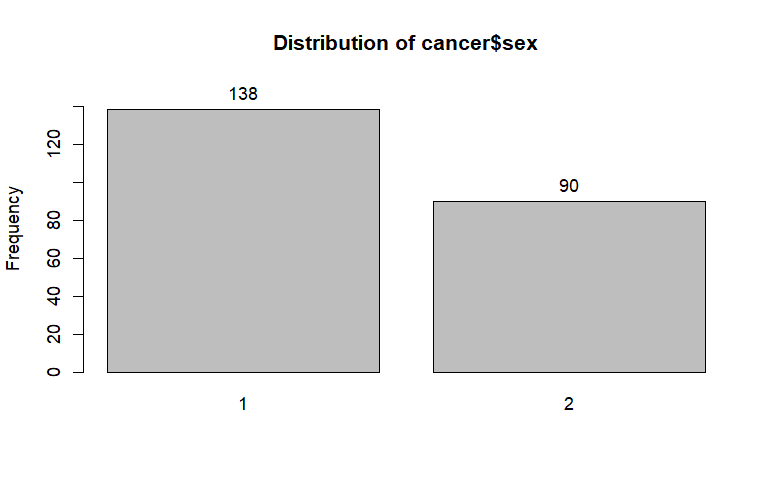

```r
#Provide percentage of factor variable
epiDisplay::tab1(cancer$sex, graph=TRUE)
```

```
cancer$status :
        Frequency Percent Cum. percent
1              63    27.6         27.6
2             165    72.4        100.0
  Total       228   100.0        100.0
```

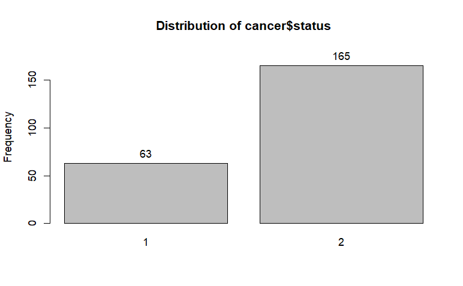

```r
epiDisplay::tab1(cancer$status, graph=TRUE)
```

60,5% parients is male 72,4% patients dead and 27,6% censored

```
cancer$sex :
        Frequency Percent Cum. percent
Male          138    60.5         60.5
Female         90    39.5        100.0
  Total       228   100.0        100.0
```

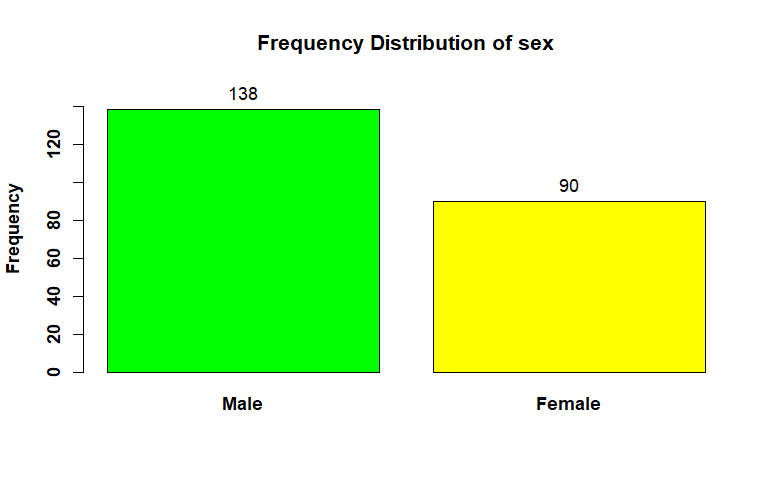

```r
#Frequency Table of Sex

# Convert 'sex' variable to factor with custom labels
cancer$sex <- factor(cancer$sex, levels = c(1, 2), labels = c("Male", "Female"))

#Convert 'status' variable to factor
cancer$status <- factor(cancer$status, levels = c(1,2), labels = c("censored","dead"))

epiDisplay::tab1(cancer$sex,
main="Frequency Distribution of sex",
col=c("green", "yellow"),
font.lab=2,
font.axis=2)
```

```
cancer$status :
         Frequency Percent Cum. percent
censored        63    27.6         27.6
dead           165    72.4        100.0
  Total        228   100.0        100.0
```

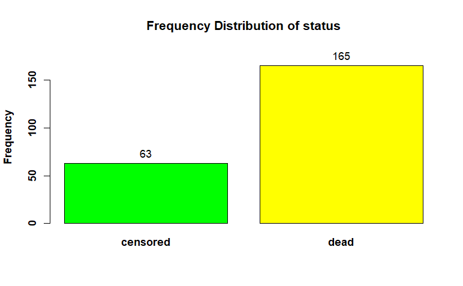

```r
epiDisplay::tab1(cancer$status,
main="Frequency Distribution of status",
col=c("green", "yellow"),
font.lab=2,
font.axis=2)
```

```r
#Pivot table for Gender (rows) and Section (column)
library(pivottabler)

pivottabler::qpvt(cancer,"sex","status",
                  c("Mean age"="mean(age, na.rm=TRUE)",
                    "SD age"="sd(age, na.rm=TRUE)",
                    "Median age"="median(age, na.rm=TRUE)",
                    "Min age"="min(age, na.rm=TRUE)",
                    "Max age"="max(age, na.rm=TRUE)"),
                  formats=list("%.0f","%.1f"))
```

```
        censored                                        dead                                            Total
        Mean age  SD age  Median age  Min age  Max age  Mean age  SD age  Median age  Min age  Max age  Mean age  SD age  Median age  Min age  Max age
Male          61    10.5          64       39       77        64     8.8        64.5       40       82        63     9.1          64       39       82
Female        60     9.3          59       41       77        62     8.5          62       44       76        61     8.8          61       41       77
Total         60     9.7          62       39       77        63     8.7          64       40       82        62     9.1          63       39       82
```

Mean of age :62(9.1) or median 63(39-82) Mean age of female 61(8,8) and median 61(41-7) Mean ge of male 63(9.1) and median 64(39-82)

|  | Sample Size | No. Miss. | Mean | Median | Std Dev | Midspread |
| --- | --- | --- | --- | --- | --- | --- |
| censored | 63 | 0 | 363.46 | 284 | 221.136 | 207 |
| dead | 165 | 0 | 283.00 | 226 | 202.805 | 252 |

Mean time to event (dead) is 283 days SD 202.81 days Mean time to censored is 363,5 days SD 221,14 days

```r
#Change the dataset to tibble
as_tibble(cancer)
```

| inst | time | status | age | sex | ph.ecog | ph.karno | pat.karno | meal.cal | wt.loss |
| --- | --- | --- | --- | --- | --- | --- | --- | --- | --- |
| 3 | 306 | dead | 74 | Male | 1 | 90 | 100 | 1175 | NA |
| 3 | 455 | dead | 68 | Male | 0 | 90 | 90 | 1225 | 15 |
| 3 | 1010 | censored | 56 | Male | 0 | 90 | 90 | NA | 15 |
| 5 | 210 | dead | 57 | Male | 1 | 90 | 60 | 1150 | 11 |
| 1 | 883 | dead | 60 | Male | 0 | 100 | 90 | NA | 0 |
| 12 | 1022 | censored | 74 | Male | 1 | 50 | 80 | 513 | 0 |
| 7 | 310 | dead | 68 | Female | 2 | 70 | 60 | 384 | 10 |
| 11 | 361 | dead | 71 | Female | 2 | 60 | 80 | 538 | 1 |
| 1 | 218 | dead | 53 | Male | 1 | 70 | 80 | 825 | 16 |
| 7 | 166 | dead | 61 | Male | 2 | 70 | 70 | 271 | 34 |

[output cut: 218 more lines]

```r
cancer <- as_tibble(cancer)
cancer
```

| inst | time | status | age | sex | ph.ecog | ph.karno | pat.karno | meal.cal | wt.loss |
| --- | --- | --- | --- | --- | --- | --- | --- | --- | --- |
| 3 | 306 | dead | 74 | Male | 1 | 90 | 100 | 1175 | NA |
| 3 | 455 | dead | 68 | Male | 0 | 90 | 90 | 1225 | 15 |
| 3 | 1010 | censored | 56 | Male | 0 | 90 | 90 | NA | 15 |
| 5 | 210 | dead | 57 | Male | 1 | 90 | 60 | 1150 | 11 |
| 1 | 883 | dead | 60 | Male | 0 | 100 | 90 | NA | 0 |
| 12 | 1022 | censored | 74 | Male | 1 | 50 | 80 | 513 | 0 |
| 7 | 310 | dead | 68 | Female | 2 | 70 | 60 | 384 | 10 |
| 11 | 361 | dead | 71 | Female | 2 | 60 | 80 | 538 | 1 |
| 1 | 218 | dead | 53 | Male | 1 | 70 | 80 | 825 | 16 |
| 7 | 166 | dead | 61 | Male | 2 | 70 | 70 | 271 | 34 |

[output cut: 218 more lines]

```r
summary(cancer)
```

```
      inst          time           status         age           sex      ph.ecog       ph.karno       pat.karno      meal.cal       wt.loss
 1      : 36   Min.   :   5   censored: 63   Min.   :39.0   Male  :138   0   : 63   Min.   : 50.0   Min.   : 30   Min.   :  96   Min.   :-24.00
 12     : 23   1st Qu.: 167   dead    :165   1st Qu.:56.0   Female: 90   1   :113   1st Qu.: 75.0   1st Qu.: 70   1st Qu.: 635   1st Qu.:  0.00
 13     : 20   Median : 256                  Median :63.0                2   : 50   Median : 80.0   Median : 80   Median : 975   Median :  7.00
 3      : 19   Mean   : 305                  Mean   :62.4                3   :  1   Mean   : 81.9   Mean   : 80   Mean   : 929   Mean   :  9.83
 11     : 18   3rd Qu.: 396                  3rd Qu.:69.0                NA's:  1   3rd Qu.: 90.0   3rd Qu.: 90   3rd Qu.:1150   3rd Qu.: 15.75
 (Other):111   Max.   :1022                  Max.   :82.0                           Max.   :100.0   Max.   :100   Max.   :2600   Max.   : 68.00
 NA's   :  1                                                                        NA's   :1       NA's   :3     NA's   :47     NA's   :14
```

# Survival Curves

```r
# Create survival curve
s <- Surv(cancer$time, cancer$status)
```

```r
# Fit the survival analysis 1=censored, 2=dead
survfit(s~1)
```

```
Call: survfit(formula = s ~ 1)

       n nevent  rmean*
(s0) 228      0 376.275
dead 228    165 645.725
   *restricted mean time in state (max time = 1022 )
```

```r
survfit(Surv(time, status)~1, data=cancer)
```

```
Call: survfit(formula = Surv(time, status) ~ 1, data = cancer)

       n nevent  rmean*
(s0) 228      0 376.275
dead 228    165 645.725
   *restricted mean time in state (max time = 1022 )
```

```r
sfit <- survfit(Surv(time, status)~1, data=cancer)
sfit
```

```
Call: survfit(formula = Surv(time, status) ~ 1, data = cancer)

       n nevent  rmean*
(s0) 228      0 376.275
dead 228    165 645.725
   *restricted mean time in state (max time = 1022 )
```

```r
summary(sfit)
```

[output not shown]

```r
# Compare the survival time between male and female
sfit <- survfit(Surv(time, status)~sex, data=cancer)
sfit
summary(sfit)
```

[output not shown]

```r
# ?summary.survfit
range(cancer$time)
seq(0, 1100, 100)
```

[output not shown]

```r
summary(sfit, times=seq(0, 1000, 100))
```

[output not shown]

Kaplan-Meier Plots

```r
sfit <- survfit(Surv(time, status)~sex, data=cancer)
plot(sfit)
```

[output not shown]

```r
library(survminer)
ggsurvplot(sfit)
```

[output not shown]

```r
ggsurvplot(sfit, conf.int=TRUE, pval=TRUE, risk.table=TRUE,
           legend.labs=c("Male", "Female"), legend.title="Sex",
           palette=c("dodgerblue2", "orchid2"),
           title="Kaplan-Meier Curve for cancer Cancer Survival",
           risk.table.height=.15)
```

[output not shown]

```r
# Fit a Cox proportional hazards model
cox_fit <- coxph(Surv(time, status) ~ age + sex + ph.ecog, data=cancer)

# Summarize the Cox model
summary(cox_fit)
```

[output not shown]

```r
# Visualize the Cox proportional hazards model results
ggforest(cox_fit, data = cancer)
```

[output not shown]